# Math311_HW3

Jackson Evans

4/21/2021

Question 5) This will mostly be simulations, find the analytic work uploaded.

Median:

```r
n<-5
vector<- c(1,seq(from = 5, to = 100, by = 5))
medians<-NULL
median_sims<- NULL
var_sims<-NULL
set.seed(157)
for(j in 1:21){
  for(i in 1:10000){
    dist<-rexp(n,1/vector[j])
    medians[i]<-median(dist)
  }
  median_sims[j]<-mean(medians) #provides expected medians for each set of 5 exp(lambda) random variables
  var_sims[j]<-var(medians)
}

median_biases<-median_sims-vector #these seem to be decreasing at a rate, let's divide by the lambda values
median_sims/vector #all these values seem to be approximate
```

```
##  [1] 0.7850619 0.7799586 0.7911084 0.7833217 0.7849205 0.7769330 0.7834816
##  [8] 0.7860720 0.7836564 0.7829513 0.7763284 0.7878356 0.7861510 0.7768340
## [15] 0.7843890 0.7802493 0.7803603 0.7744198 0.7801762 0.7826143 0.7786524
```

```r
mean(median_sims/vector) #therefore we can normalize by multiplying lambda by 1/0.7821655
```

```
## [1] 0.7821655
```

```r
#MSE is variance plus square of bias
median_mse<-var_sims + (median_biases)^2
median_mse
```

```
##  [1]    0.2654162    6.3750286   26.4753878   58.2028171  106.6061968
##  [6]  162.6818196  233.5728692  322.4582170  415.0551125  535.7370920
## [11]  635.5055365  780.5829982  930.3067001 1091.7855320 1303.2778503
## [16] 1466.1564645 1692.1724967 1874.9022616 2101.9845224 2391.1197080
## [21] 2555.7100972
```

As shown, the bias of the median estimator is 0.7821655 when subtracting then dividing lambda from the estimator. Therefore by dividing the median estimator by 0.78 we can unbias the estimator. The final vector of 21 values are the MSE estimates for lambda values of 1, 5, 10, 15, 20, 25, 30, 35, 40, 45, 50, 55, 60, 65, 70, 75, 80, 85, 90, 95, 100.

Max(x)-Min(x):

```r
n<-5
vector<- c(1,seq(from = 5, to = 100, by = 5))
max_min<-NULL
max_min_sims<- NULL
var_sims<-NULL
set.seed(157)
for(j in 1:21){
  for(i in 1:10000){
    dist<-rexp(n,1/vector[j])
    max_min[i]<-max(dist)-min(dist)
  }
  max_min_sims[j]<-mean(max_min) #provides expected min-max for each set of 5 exp(lambda) random variables
  var_sims[j]<-var(max_min)
}

max_min_biases<-max_min_sims-vector #these are the biases based on lambda values
max_min_sims/vector #they seem to all be around 2
```

```
##  [1] 2.098043 2.084217 2.078357 2.088760 2.081464 2.076189 2.087441 2.073249
##  [9] 2.085522 2.096374 2.080149 2.096048 2.075996 2.092188 2.091538 2.081445
## [17] 2.084968 2.075982 2.086659 2.083014 2.084053
```

```r
mean(max_min_sims/vector) #seems we can also unbias this by dividing by 2.
```

```
## [1] 2.084841
```

```r
max_min_mse<-var_sims + (max_min_biases)^2
max_min_mse
```

```
##  [1]     2.68196    65.41039   260.00076   584.24356  1017.00836  1602.50821
##  [7]  2342.67191  3119.99984  4164.81908  5376.36944  6484.96595  7980.83012
## [13]  9230.63491 11067.34434 13143.29590 14500.75264 16805.99918 18689.70194
## [19] 21271.73638 23665.58916 25697.01925
```

As shown, the bias of the median estimator is 2.09 when subtracting then dividing lambda from the estimator. Therefore by dividing the median estimator by 2.09 we can unbias the estimator.The final vector for the 21 values of lambda are shown in the vector above.

```r
n<-5
vector<- c(1,seq(from = 5, to = 100, by = 5))
mid3<-NULL
mid3_sims<- NULL
var_sims<-NULL
set.seed(157)
for(j in 1:21){
  for(i in 1:10000){
    dist<-rexp(n,1/vector[j])
    mid3[i]<-sum(dist)-max(dist)-min(dist)
  }
  mid3_sims[j]<-mean(mid3) #provides expected min-max for each set of 5 exp(lambda) random variables
  var_sims[j]<-var(mid3)
}

mid3_biases<-mid3_sims-vector #these are the biases based on lambda values
mid3_sims/vector #they seem to all be around 2.5
```

```
##  [1] 2.524735 2.510223 2.534059 2.517844 2.520491 2.506599 2.526033 2.525656
##  [9] 2.516647 2.518484 2.493157 2.528236 2.530687 2.511583 2.517462 2.506655
## [17] 2.515707 2.491688 2.507847 2.514556 2.510861
```

```r
mean(mid3_sims/vector) #seems we can also unbias this by dividing by 2.5.
```

```
## [1] 2.515677
```

```r
mid3_mse<-var_sims + (mid3_biases)^2
mid3_mse
```

```
##  [1]     3.969795    96.218744   399.877056   882.174018  1580.744741
##  [6]  2422.851346  3574.614406  4839.388861  6232.264592  7955.005405
## [11]  9406.699134 11964.499583 14259.900379 16495.542511 19340.707161
## [16] 21880.909617 25199.691418 27442.976098 31294.762401 35582.372381
## [21] 38648.556823
```

As shown, the bias of the median estimator is 2.5 when subtracting then dividing lambda from the estimator. Therefore by dividing the median estimator by 2.5 we can unbias the estimator. The final vector for the 21 values of lambda are shown in the vector above.

To compare these three, let’s make a graph but consider larger lambda values:

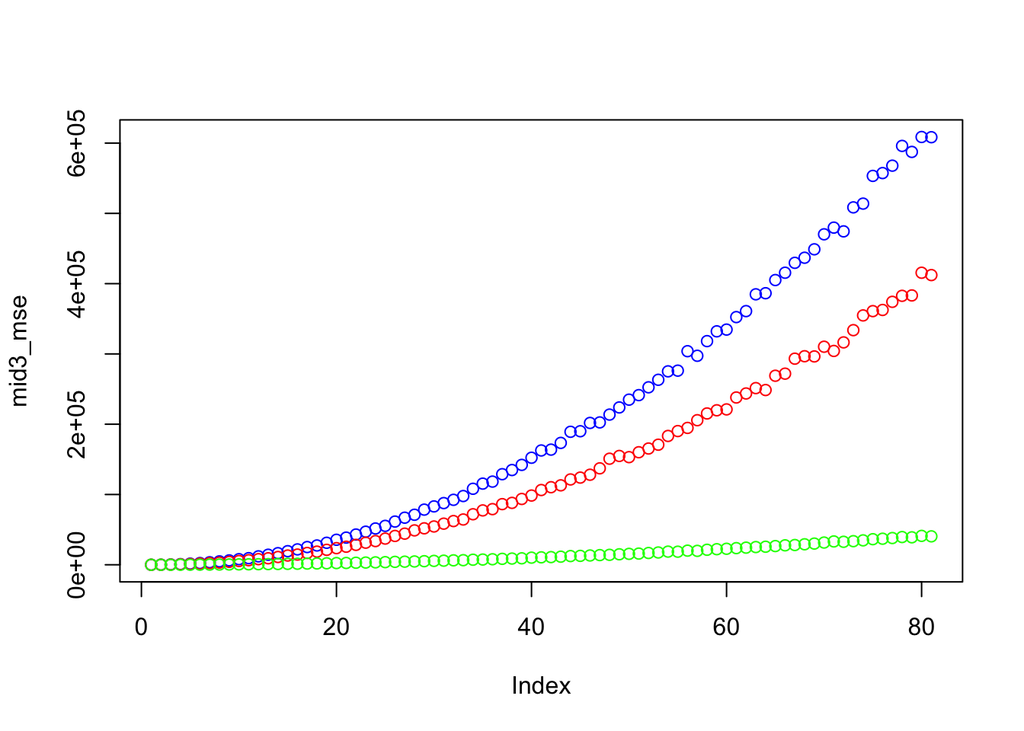

```r
#median
n<-5
vector<- c(1,seq(from = 5, to = 400, by = 5))
medians<-NULL
median_sims<- NULL
var_sims<-NULL
set.seed(157)
for(j in 1:81){
  for(i in 1:10000){
    dist<-rexp(n,1/vector[j])
    medians[i]<-median(dist)
  }
  median_sims[j]<-mean(medians) #provides expected medians for each set of 5 exp(lambda) random variables
  var_sims[j]<-var(medians)
}

median_biases<-median_sims-vector #these seem to be decreasing at a rate, let's divide by the lambda values

#MSE is variance plus square of bias
median_mse<-var_sims + (median_biases)^2

#max-min
max_min<-NULL
max_min_sims<- NULL
var_sims<-NULL
set.seed(157)
for(j in 1:81){
  for(i in 1:10000){
    dist<-rexp(n,1/vector[j])
    max_min[i]<-max(dist)-min(dist)
  }
  max_min_sims[j]<-mean(max_min) #provides expected min-max for each set of 5 exp(lambda) random variables
  var_sims[j]<-var(max_min)
}

max_min_biases<-max_min_sims-vector #these are the biases based on lambda values
max_min_mse<-var_sims + (max_min_biases)^2


#1/3 (sum(x)-min(x)-max(x)) = 1/3(sum(middle three values))
mid3<-NULL
mid3_sims<- NULL
var_sims<-NULL
set.seed(157)
for(j in 1:81){
  for(i in 1:10000){
    dist<-rexp(n,1/vector[j])
    mid3[i]<-sum(dist)-max(dist)-min(dist)
  }
  mid3_sims[j]<-mean(mid3) #provides expected min-max for each set of 5 exp(lambda) random variables
  var_sims[j]<-var(mid3)
}
mid3_biases<-mid3_sims-vector #these are the biases based on lambda values
mid3_mse<-var_sims + (mid3_biases)^2


plot(mid3_mse, col="blue")
#par(new=TRUE)
points(max_min_mse, col="red")
#par(new=TRUE)
points(median_mse, col="green")
```

The above graphs show the MSE for the median estimator (green), the max-min estimator (red) and the middle 3 estimator (blue) to estimate lambda. The x axis is actually lambda values [1,5,10,…,400]. Therefore we can see that the median estimator has the smallest MSE, and is therefore the best estimator of the bunch for lambda, followed by max-min, followed by the middle 3. The median is also the easiest to describe analytically.